# Hoja de Ejercicios 2 - Parte 2

Aprendizaje Estadístico y Toma de Decisiones.

Juan José Martín, Marina Moreno, Christian Strasser, Maria del Mar Bibiloni.

## Ejercicio 7

**Cargue los datos del Problema 6 otra vez y obtén el *k* óptimo mediante una Validación Cruzada 10-Veces: descargue la *package KODAMA* y utilice la función “*KNN.CV()*”, mire las páginas 7-8 de la documentación de la *package KODAMA*.**

Cargamos e inicializamos las variables.

```r
library(KODAMA)

data_pro = read.csv("datasets/Pro.csv")
data = data_pro[,3:10]
labels = data_pro[,2]
runns = 10 # Número de Cross-Validations
knn_c = c()
cv.error10 = c()
```

A continuación realizamos *k* veces (12 veces en nuesttro caso) la función *KNN()* de *KODAMA* y usamos los datos obtenidos de esta función para realizar una *Validación Cruzada*, en este caso, de 10-veces, para así obtener cada vez una media del error de predicción en cada validación.

```r
for(i in 1:12){
  # Obtener los 'runns' conjuntos de predicciones
  knn_t = knn.double.cv(Xdata = data, Ydata = labels, compmax = i, runn = runns)
  for(j in 1:runns){ # Obtener los 'runns' errores de predicciones
    knn_c[j] = (knn_t$results[[j]]$conf[2] + knn_t$results[[j]]$conf[3]) /
      (knn_t$results[[j]]$conf[1] + knn_t$results[[j]]$conf[2] +
         knn_t$results[[j]]$conf[3] + knn_t$results[[j]]$conf[4])
  }
  cv.error10[i] = mean(knn_c) # Obtener la media de los errores de predicción
}
```

Finalmente, visualizamos nuestro conjunto de errores de predicción *cv.error10* y obtenemos el *k* óptimo. En este caso, el *k* óptimo es el valor entre 1 y 12 en el que obtenemos el menor error de predicción. Además, el valor óptimo *k* y el menor error de predicción depende en parte de la aleatoriedad en la que el método *KNN()* de *KODAMA* escoge las variables de nuestros conjunto de datos.

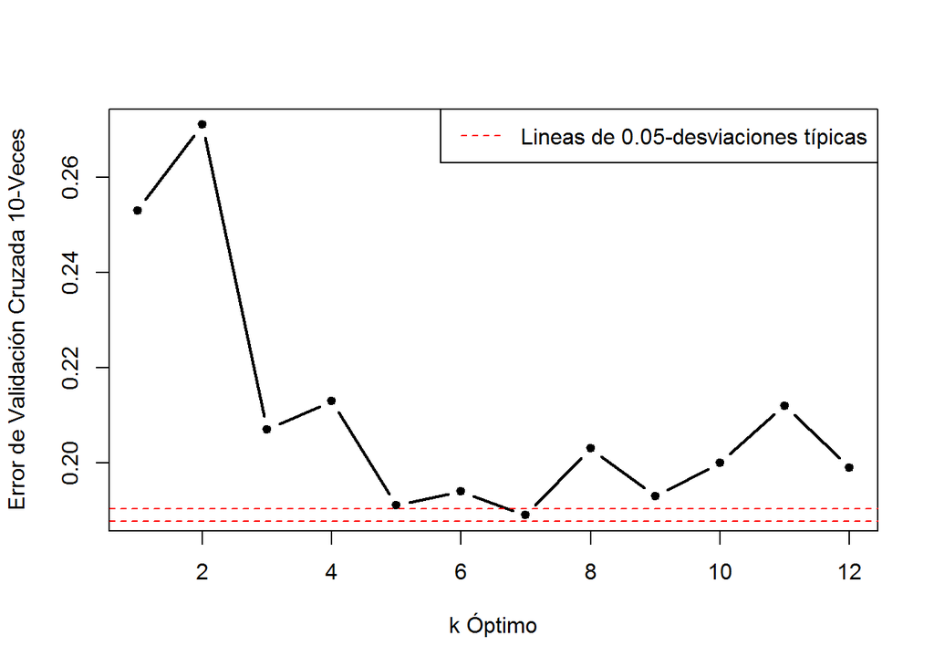

```r
plot(1:12, cv.error10, xlab="k Óptimo", ylab="Error de Validación Cruzada 10-Veces", type="b", pch=20, lwd=2)
min.point = min(cv.error10)
sd.points = sd(cv.error10)
abline(h=min.point + 0.05 * sd.points, col="red", lty="dashed")
abline(h=min.point - 0.05 * sd.points, col="red", lty="dashed")
legend("topright", "Lineas de 0.05-desviaciones típicas", lty="dashed", col="red")
```

## Ejercicio 8

Para realizar el ejercicio necesitamos cargar las librerias *ISLR* y *boot*.

```r
library(ISLR)
library(boot)
```

El conjunto de datos **Wage** contiene información de 3000 hombres trabajadores de la región Mid-Atlantic de Estados Unidos. Calculemos las dimensiones del data frame.

```r
Wage=na.omit(Wage)
dim(Wage)
```

```
## [1] 3000   11
```

Ahora, veamos que idica cada una de las columnas.

```r
names(Wage)
```

```
##  [1] "year"       "age"        "maritl"     "race"       "education"
##  [6] "region"     "jobclass"   "health"     "health_ins" "logwage"
## [11] "wage"
```

Según la documentación de R, cada una de estas variables contiene la siguiente información.

- *year*: Año en que se recogió la información salarial.
- *age*: Años de experiencia.
- *maritl:* Factor que indica el estado civil.
1. Nunca casado.
2. Casado.
3. Viudo.
4. Divorciado.
- *race:* Factor que indica la raza.
1. Blanco.
2. Negro.
3. Asiático.
4. Otros.
- *education:* Factor que indica el nivel de educación.
1. Inferior que eduación secundaria.
2. Educación secundaria.
3. Educación superior.
4. Graduado en la Universidad.
5. Estudios de post-grado.
- *region:* Región del País (de Mid-Atlantic).
- *jobclass:* Factor que indica el tipo de trabajo.
1. Industrial.
2. Información.
- *health:* Factor que indica el nivel de salud.
1. Bien o peor que bien.
2. Muy bien o más.
- *health_ins:* Factor que indica si el trabajador tiene seguro de salud.
1. Sí.
2. No.
- *logwage:* Logaritmo del salario.
- *wage:* Salario bruto.

La variable dependiente es *wage* (o *logwage*) y las demás variables son posibles variables explicativas del salario de los trabajadores. Antes de empezar el análisis, visualizemos algunas de las filas del data frame.

```r
head(Wage,20)
```

| year | age | maritl | race | education | region | jobclass | health | health_ins | logwage | wage |
| --- | --- | --- | --- | --- | --- | --- | --- | --- | --- | --- |
| 2006 | 18 | 1. Never Married | 1. White | 1. < HS Grad | 2. Middle Atlantic | 1. Industrial | 1. <=Good | 2. No | 4.318063 | 75.04315 |
| 2004 | 24 | 1. Never Married | 1. White | 4. College Grad | 2. Middle Atlantic | 2. Information | 2. >=Very Good | 2. No | 4.255273 | 70.47602 |
| 2003 | 45 | 2. Married | 1. White | 3. Some College | 2. Middle Atlantic | 1. Industrial | 1. <=Good | 1. Yes | 4.875061 | 130.98218 |
| 2003 | 43 | 2. Married | 3. Asian | 4. College Grad | 2. Middle Atlantic | 2. Information | 2. >=Very Good | 1. Yes | 5.041393 | 154.68529 |
| 2005 | 50 | 4. Divorced | 1. White | 2. HS Grad | 2. Middle Atlantic | 2. Information | 1. <=Good | 1. Yes | 4.318063 | 75.04315 |
| 2008 | 54 | 2. Married | 1. White | 4. College Grad | 2. Middle Atlantic | 2. Information | 2. >=Very Good | 1. Yes | 4.845098 | 127.11574 |
| 2009 | 44 | 2. Married | 4. Other | 3. Some College | 2. Middle Atlantic | 1. Industrial | 2. >=Very Good | 1. Yes | 5.133021 | 169.52854 |
| 2008 | 30 | 1. Never Married | 3. Asian | 3. Some College | 2. Middle Atlantic | 2. Information | 1. <=Good | 1. Yes | 4.716003 | 111.72085 |
| 2006 | 41 | 1. Never Married | 2. Black | 3. Some College | 2. Middle Atlantic | 2. Information | 2. >=Very Good | 1. Yes | 4.778151 | 118.88436 |
| 2004 | 52 | 2. Married | 1. White | 2. HS Grad | 2. Middle Atlantic | 2. Information | 2. >=Very Good | 1. Yes | 4.857332 | 128.68049 |

[output cut: 10 more lines]

De todas las posibles variables explicativas, seleccionamos *age*. Así, vamos a estudiar que relación hay entre la variable dependiente *wage* y la variable independiente *age*. La idea es estimar una función que modele esta relación para poder hacer predicciones del salario de un trabajador, dados sus años de experiencia. Para empezar, visualizamos los datos.

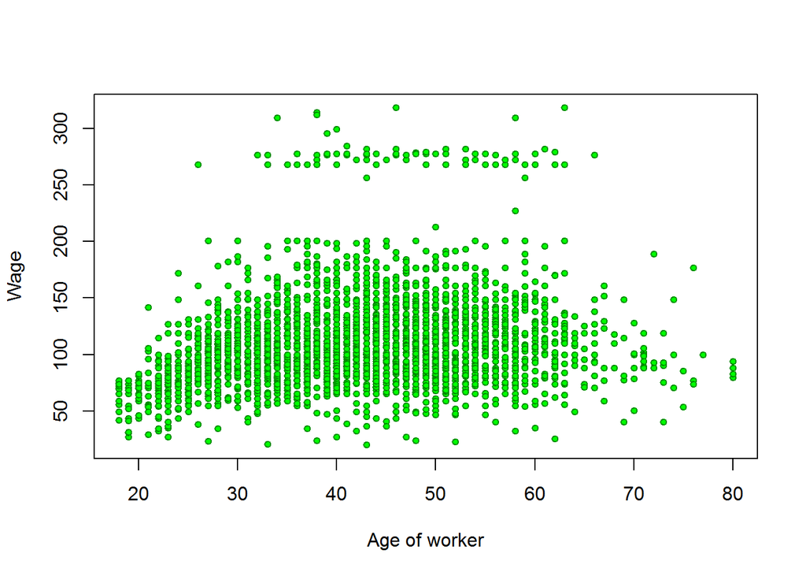

```r
attach(Wage)
plot(wage ~ age, pch=21, cex=0.75, bg="green", col="green4", xlab="Age of worker", ylab="Wage")
```

Si observamos la gráfica anterior, parece que hay una relación lineal entre las variables, o cuadràtica de coeficiente principal muy cercano a cero. A continuación, utilizaremos el mètodo de validación cruzada para diferentes valores de $K$ para encontrar el modelo que mejor se ajusta a la nube de puntos.

- $K=5$.

Para realizar la validación cruzada con k=5 hay que seleccionar aleatóriamente 5 subconjuntos de trabajadores. Luego, se realizan 5 iteraciones. En cada iteración se toma uno de los $k$ subconjuntos como el conjunto de validación y los otros como conjunto de entrenamiento. Así, se obtienen 5 errores de prueba estimados en cada una de las iteraciones, con cada uno de los 5 conjuntos de validación. Finalmente, se calcula la media del error quadràtico cometido en el conjunto de validación, llamémoslo $CV_{(5)}$.

La función *cv.glm()* de `R` realiza el método de validación cruzada con el valor de $K$ que se indique y devuelve el error $CV_{(k)}$. Por tanto, sólo falta escoger que polinomios son candidatos para estimar la función de predicción. Tal como indica el enunciado, tomaremos polinomios de grado 1 hasta 10.

Para calcular el error de validación $CV_{(k)}$ , implementmos la siguiente función

```r
cross_val = function(x, y, k=NA, degree=1:10) {

  loocv = function(fit) {
    h = lm.influence(fit)$h
    mean((residuals(fit) / (1-h))^2)
  }

  cv_error = NA
  data = data.frame(x1=x, y1=y)

  for(d in degree){
    glm_fit = glm(y1~poly(x1, d), data=data)

    if (is.na(k)) {
      cv_error[d] = loocv(glm_fit)
    } else {
      cv_error[d] = cv.glm(data, glm_fit, K=k)$delta[1]
    }
  }

  return (cv_error)
}
```

Veamos que polinomio tiene associado un valor menor del error $CV_{(5)}$.

```r
set.seed(357)
cv_error5=cross_val(x=age, y=wage, k=5)
cv_error5
```

```
##  [1] 1675.980 1600.905 1598.536 1596.181 1596.161 1592.187 1592.718
##  [8] 1595.665 1592.688 1595.681
```

```r
cv_min=min(cv_error5)
which(cv_error5==cv_min)
```

```
## [1] 6
```

Por tanto, el polinomio que mejor predice el salario en función de los años de experciencia, según nuestros datos, es de grado seis. Ahora, para ver la gràfica de los errores CV implementamos la siguiente función.

```r
plot_cv_error = function(cv_error,k,col,bg,ylim, degree=1:10){
  plot(degree, cv_error, xlab="Orden", ylab=paste("Error de Validación Cruzada",k,"-Veces"), type="b", pch=21, lwd=1, col=col, bg=bg, ylim=ylim)
  min.point = min(cv_error)
  sd.points = sd(cv_error)
  abline(h=min.point + 0.2 * sd.points, col="red", lty="dashed")
  abline(h=min.point - 0.2 * sd.points, col="red", lty="dashed")
  legend("topright", "Lineas de 0.2 desviaciones típicas", lty="dashed", col="red")
}
```

Así, basta ejecutar la siguiente instrucción.

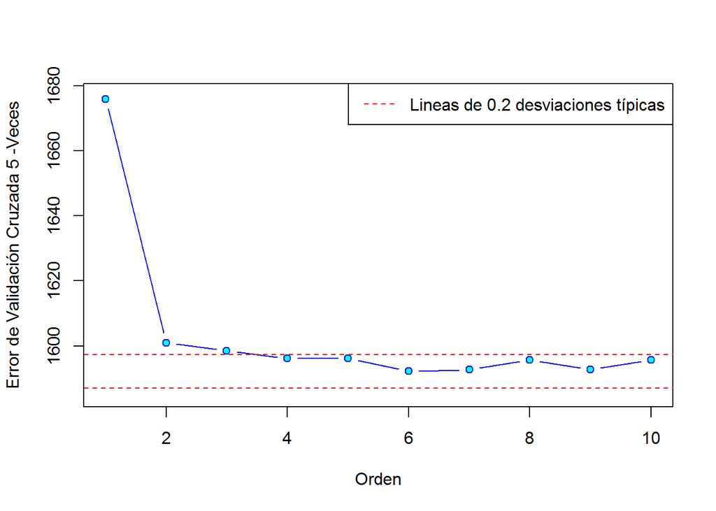

```r
plot_cv_error(cv_error5,k=5,col="blue", bg="cyan", ylim=c(1585,1677))
```

Fijémonos que el grado que comete menor error $CV_{(5)}$ es 6. Finalmente, conlcuimos que tenemos una relación polinómica de grado $6$ con los siguientes coeficientes.

```r
lm_fit6=lm(wage~poly(age, 6), data = Wage)
lm_fit6$coefficients
```

```
##   (Intercept) poly(age, 6)1 poly(age, 6)2 poly(age, 6)3 poly(age, 6)4
##     111.70361     447.06785    -478.31581     125.52169     -77.91118
## poly(age, 6)5 poly(age, 6)6
##     -35.81289      62.70772
```

Veamos como el polinomio estimado se ajusta a la nube de puntos.

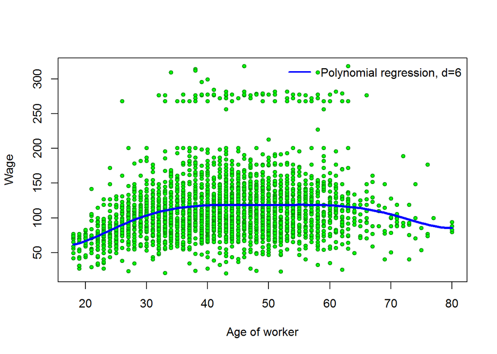

```r
plot(wage ~ age, pch=21, cex=0.75,bg="green", col="green4", xlab="Age of worker", ylab="Wage")
curve(predict(lm_fit6,data.frame(age=x)),col='blue',lwd=3,add=TRUE)
legend("topright",legend="Polynomial regression, d=6",col="blue",lty =1,lwd=2,bty ="n")
```

- $K=10$.

En este apartado repetiremos el proceso de validación cruzada con $K=10$. Así, veremos que grado del polinomio es mejor según el nuevo $K$.

```r
set.seed(78)
cv_error10=cross_val(x=age, y=wage, k=10)
cv_error10
```

```
##  [1] 1676.851 1600.046 1595.278 1596.594 1595.363 1594.351 1593.648
##  [8] 1594.101 1592.494 1595.406
```

```r
cv_min=min(cv_error10)
which(cv_error10==cv_min)
```

```
## [1] 9
```

En este caso, el menor error se comete con un polinomio de grado 9. Visualicemos los errores para cada grado.

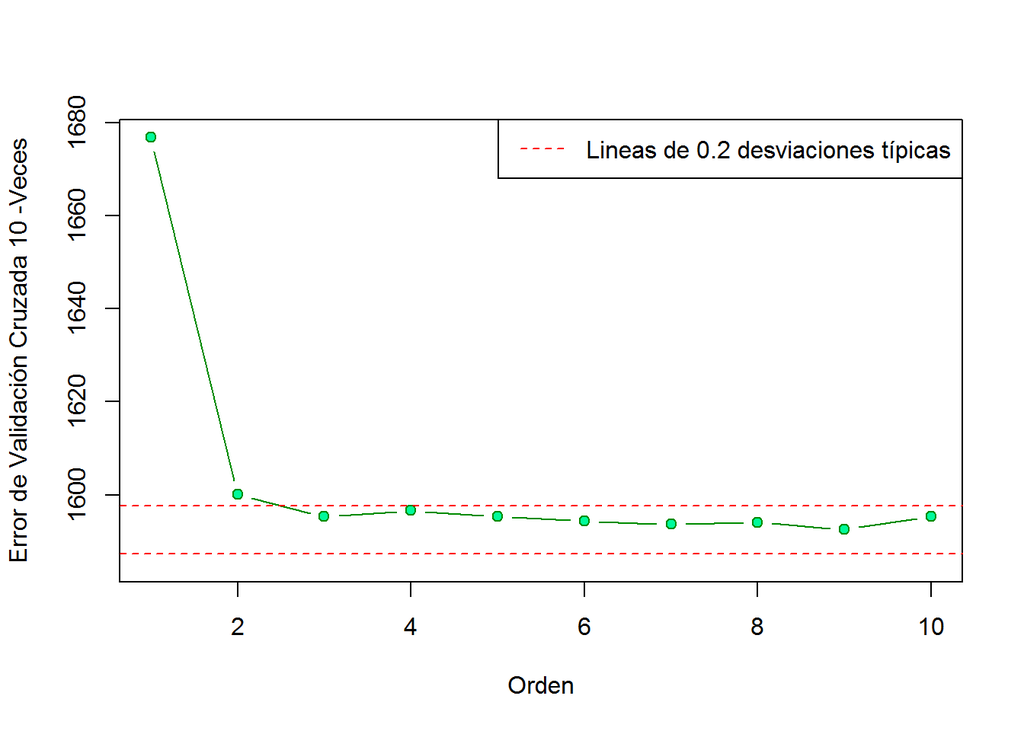

```r
plot_cv_error(cv_error10,k=10,col="green4", bg="mediumspringgreen",ylim=c(1585,1677))
```

Así, los coeficientes de la recta estimada para predecir el valor de *Waste*, según *age*, son los calculados a continuación.

```r
lm_fit9=lm(wage~poly(age, 9), data = Wage)
lm_fit9$coefficients
```

```
##   (Intercept) poly(age, 9)1 poly(age, 9)2 poly(age, 9)3 poly(age, 9)4
##     111.70361     447.06785    -478.31581     125.52169     -77.91118
## poly(age, 9)5 poly(age, 9)6 poly(age, 9)7 poly(age, 9)8 poly(age, 9)9
##     -35.81289      62.70772      50.54979     -11.25473     -83.69180
```

Ahora, viasualicemos el nuevo polinomio estimado.

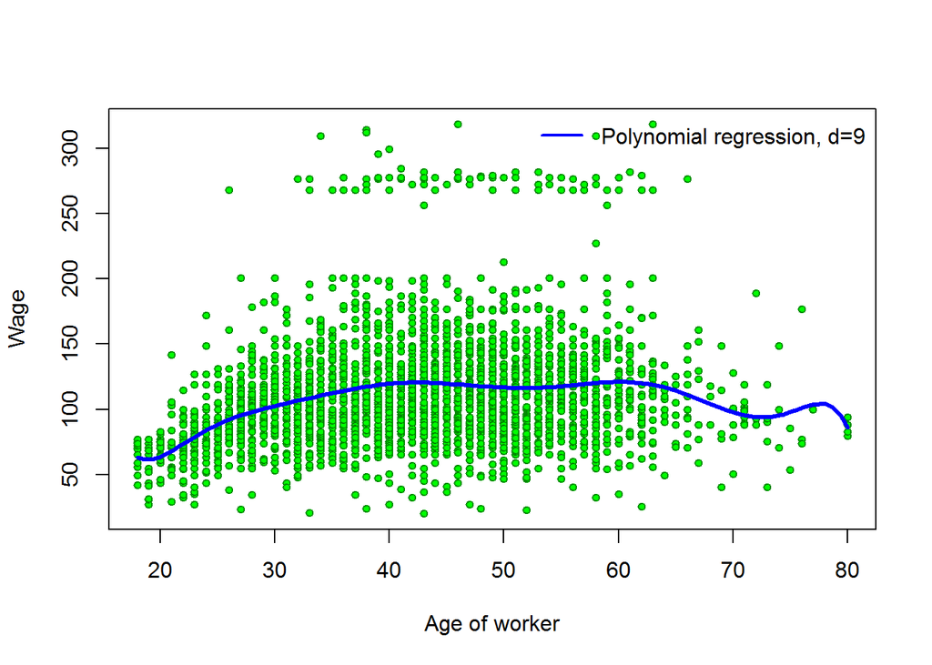

```r
plot(wage ~ age, pch=21, cex=0.75,bg="green", col="green4", xlab="Age of worker", ylab="Wage")
curve(predict(lm_fit9,data.frame(age=x)),col='blue',lwd=3,add=TRUE)
legend("topright",legend="Polynomial regression, d=9",col="blue",lty =1,lwd=2,bty ="n")
```

Notemos que el comportamiento es similar que para $d=6$, exceptuando las variaciones del salario para valores altos de años de experiencia ($>65$).

- LOOCV. $K=n$, donde $n$ es el número de observaciones (trabajadores).

De nuevo, vamos a utilizar el mètodo de validación cruzada para estimar un modelo que nos permita hacer predicciones del salario de los trabajadores en función de los años de experiencia. En este caso, tomamos $K=n=3000$.

```r
set.seed(11235)
cv_error3000=cross_val(x=age, y=wage)
cv_error3000
```

```
##  [1] 1676.235 1600.529 1595.960 1594.596 1594.879 1594.119 1594.145
##  [8] 1594.975 1593.356 1594.232
```

```r
cv_min=min(cv_error3000)
which(cv_error3000==cv_min)
```

```
## [1] 9
```

Como podemos observar, el resultado es el mismo que en el caso anterior: el mejor polinomio es de grado 9. Dibujemos la gràfica de los errores.

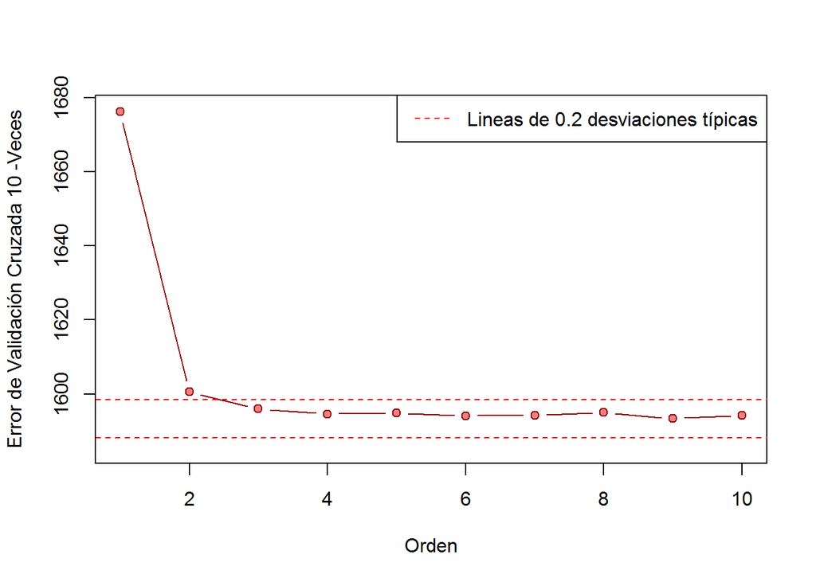

```r
plot_cv_error(cv_error3000,k=10,col="darkred", bg="lightcoral",ylim=c(1585,1677))
```

Así, para $k=n$, concluimos que la función de nuestro modelo de predicción es el polinomio de grado 9 obtenido en el apartado anterior, con $k=10$.

Para poder comparar el resultado del método de validación cruzada para $K=5,10$ y $n$, vamos a dibujar los errores $CV_{(K)}$ en un mismo gràfico.

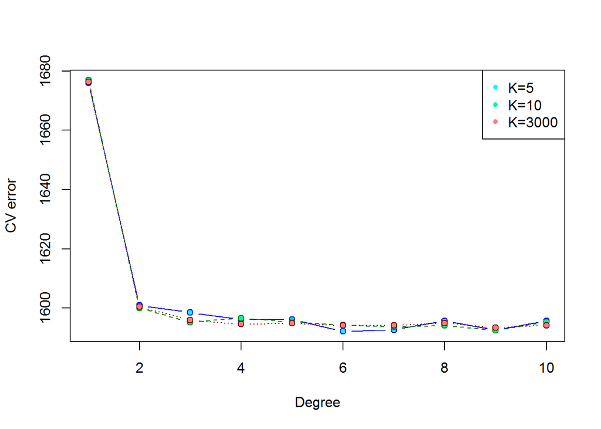

```r
matplot(1:10, cbind(cv_error5,cv_error10,cv_error3000), xlab="Degree", ylab="CV error", type="b", pch=21, lwd=1, col=c("blue","green4","darkred"), bg=c("cyan","mediumspringgreen","lightcoral"))
legend("topright",legend=c("K=5","K=10","K=3000"),pch=20,col=c("cyan","mediumspringgreen","lightcoral"))
```

A partir de grado $2$ no se aprecia la diferencia, por tanto, disminuimos el rango de la variable de error $CV_{(K)}$.

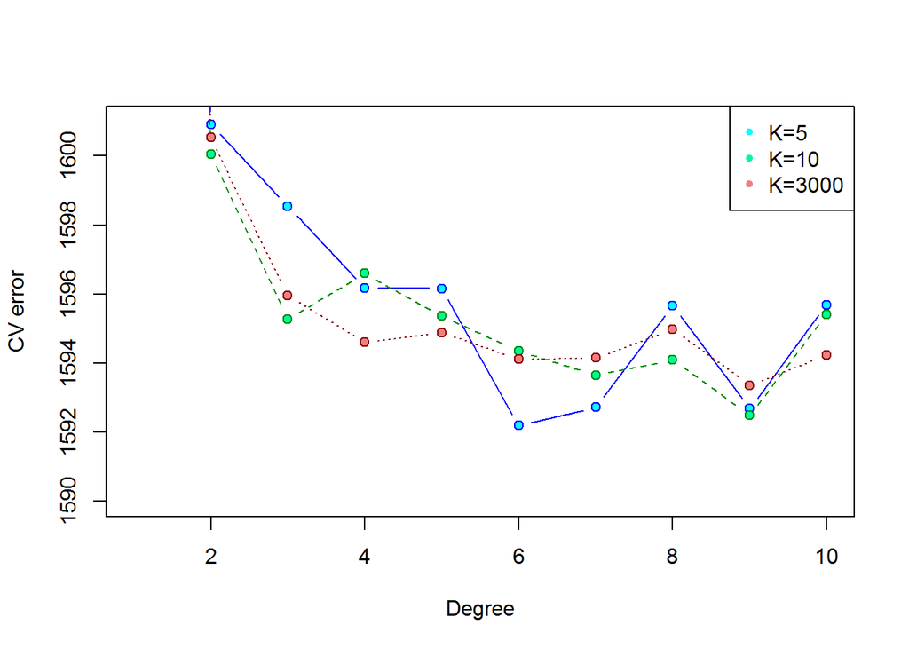

```r
matplot(1:10, cbind(cv_error5,cv_error10,cv_error3000), xlab="Degree", ylab="CV error", type="b", pch=21, lwd=1, col=c("blue","green4","darkred"), bg=c("cyan","mediumspringgreen","lightcoral"),ylim=c(1590,1601))
legend("topright",legend=c("K=5","K=10","K=3000"),pch=20,col=c("cyan","mediumspringgreen","lightcoral"))
```

```r
detach(Wage)
```

## Ejercicio 9

**Cargue las libraries *ISLR* y *boot.* Cargue la base de datos *Boston.* Haz una regresión polinomial para predecir la concentración de óxidos de nitrógeno en partes por 10 millones (*nox*) utilizando sólo la media ponderada de las distancias a cinco centros de empleo de Boston (*dis*). Utilice la validación cruzada de 5, 10 y *n* Veces (*LOOCV*) para encontrar el orden óptimo para el polinomio (considere $d \in [1; 10]$). Haz el gráfico del error de validación cruzada para cada orden del polinomio, para cada una de las 3 validaciones cruzadas. Proporcione el código y los resultados.**

```r
library(ISLR)
library(boot)
library(MASS)
```

Realizamos un pequeño exploratorio de los datos antes de empezar con el análisis.

```r
head(Boston)
```

| crim | zn | indus | chas | nox | rm | age | dis | rad | tax | ptratio | black | lstat | medv |
| --- | --- | --- | --- | --- | --- | --- | --- | --- | --- | --- | --- | --- | --- |
| 0.00632 | 18 | 2.31 | 0 | 0.538 | 6.575 | 65.2 | 4.0900 | 1 | 296 | 15.3 | 396.90 | 4.98 | 24.0 |
| 0.02731 | 0 | 7.07 | 0 | 0.469 | 6.421 | 78.9 | 4.9671 | 2 | 242 | 17.8 | 396.90 | 9.14 | 21.6 |
| 0.02729 | 0 | 7.07 | 0 | 0.469 | 7.185 | 61.1 | 4.9671 | 2 | 242 | 17.8 | 392.83 | 4.03 | 34.7 |
| 0.03237 | 0 | 2.18 | 0 | 0.458 | 6.998 | 45.8 | 6.0622 | 3 | 222 | 18.7 | 394.63 | 2.94 | 33.4 |
| 0.06905 | 0 | 2.18 | 0 | 0.458 | 7.147 | 54.2 | 6.0622 | 3 | 222 | 18.7 | 396.90 | 5.33 | 36.2 |
| 0.02985 | 0 | 2.18 | 0 | 0.458 | 6.430 | 58.7 | 6.0622 | 3 | 222 | 18.7 | 394.12 | 5.21 | 28.7 |

Según la documentación de R, cada una de estas variables contiene la siguiente información.

- crim: tasa de criminalidad per cápita por ciudad.
- zn: proporción de terrenos residenciales divididos en zonas para lotes de más de 25,000 pies cuadrados.
- indus: proporción de acres de negocios no minoristas por pueblo.
- chas: variable ficticia de Charles River (= 1 si el tramo limita con el río, 0 en caso contrario).
- nox: concentración de óxidos de nitrógeno (partes por 10 millones).
- rm: número promedio de habitaciones por vivienda.
- age: proporción de unidades ocupadas por sus propietarios construidas antes de 1940.
- dis: media ponderada de las distancias a cinco centros de empleo de Boston.
- rad: índice de accesibilidad a las autopistas radiales.
- tax: tasa de impuesto a la propiedad de valor completo por $ 10,000.
- ptratio: relación alumnos por profesor por ciudad.
- black: $1000(Bk−0.63)^2$ donde Bk es la proporción de negros por ciudad.
- lstat: estado inferior de la población (porcentaje).
- medv: valor mediano de las viviendas ocupadas por sus propietarios en miles de dólares.

La variable dependiente para este análisis será *nox* y la variable explicativa será *dis*.

```r
boston = Boston[c('dis', 'nox')]
head(boston)
```

| dis | nox |
| --- | --- |
| 4.0900 | 0.538 |
| 4.9671 | 0.469 |
| 4.9671 | 0.469 |
| 6.0622 | 0.458 |
| 6.0622 | 0.458 |
| 6.0622 | 0.458 |

```r
dim(boston)
```

```
## [1] 506   2
```

```r
summary(boston)
```

```
##       dis              nox
##  Min.   : 1.130   Min.   :0.3850
##  1st Qu.: 2.100   1st Qu.:0.4490
##  Median : 3.207   Median :0.5380
##  Mean   : 3.795   Mean   :0.5547
##  3rd Qu.: 5.188   3rd Qu.:0.6240
##  Max.   :12.127   Max.   :0.8710
```

```r
colSums(is.na(boston))
```

```
## dis nox
##   0   0
```

```r
attach(boston)
```

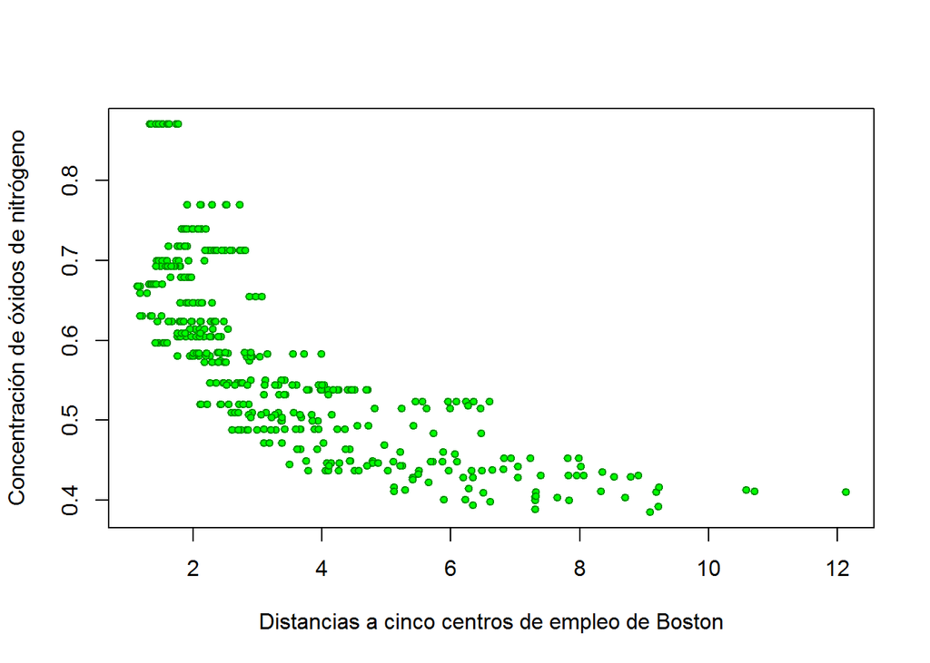

```r
plot(nox~dis, pch=21, cex=0.75, bg="green", col="green4", xlab="Distancias a cinco centros de empleo de Boston", ylab="Concentración de óxidos de nitrógeno")
```

Observando la gráfica anterior, parece que hay una correlación negativa entre ambas variables. El valor de esta correlación:

```r
corr(boston)
```

```
## [1] -0.7692301
```

- $K=5$.

Para calcular el error de validación para $k=5$, usamos la función *cross_val* que hemos implementado anteriormente.

```r
set.seed(357)
cv_error_5 = cross_val(x=dis, y=nox, k=5)
cv_error_5
```

```
##  [1] 0.005487590 0.004081652 0.003893548 0.003885327 0.004231641
##  [6] 0.005644237 0.013252852 0.009707793 0.004948646 0.020344026
```

```r
cv_min = min(cv_error_5)
which(cv_error_5==cv_min)
```

```
## [1] 4
```

El polinómio que mejor predice la concentración de óxidos de nitrógeno en función a las medias ponderadas de las distancias a cinco centros de empleos en Bostos, según estos datos, es cuatro.

Generamos la gráfica de los error de CV mediante la función *plot_cv_error*, implementada también anteriormente.

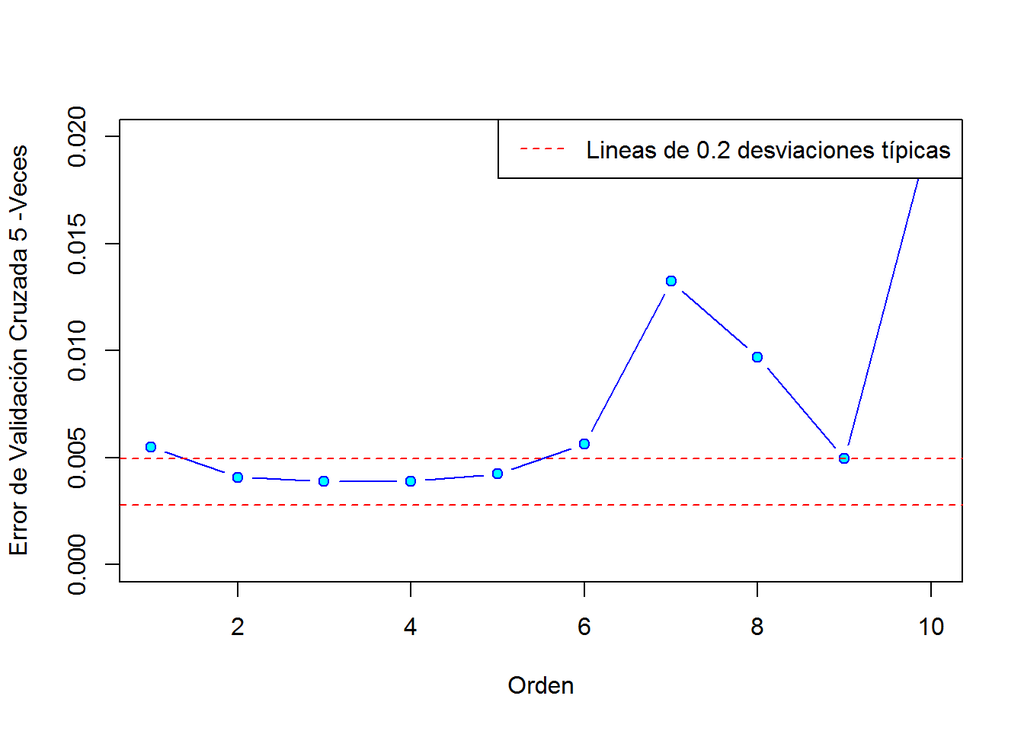

```r
plot_cv_error(cv_error_5, k=5, col="blue", bg="cyan", ylim=c(0, 0.02))
```

```r
lm_fit_4 = lm(nox~poly(dis, 4))
lm_fit_4$coefficients
```

```
##   (Intercept) poly(dis, 4)1 poly(dis, 4)2 poly(dis, 4)3 poly(dis, 4)4
##    0.55469506   -2.00309590    0.85632995   -0.31804899    0.03354668
```

Veamos como el polinomio estimado se ajusta a la nube de puntos.

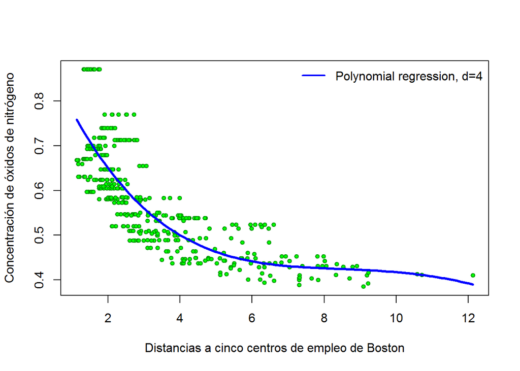

```r
plot(nox~dis, pch=21, cex=0.75, bg="green", col="green4", xlab="Distancias a cinco centros de empleo de Boston", ylab="Concentración de óxidos de nitrógeno")
curve(predict(lm_fit_4, data.frame(dis=x)), col='blue', lwd=3, add=TRUE)
legend("topright", legend="Polynomial regression, d=4", col="blue", lty =1, lwd=2, bty ="n")
```

Como podemos observar, la concentración de óxidos de nitrógeno disminuye a medida que nos alejamos de los centros de empleo de Boston.

- $K=10$.

Repetimos el mismo proceso para $k=10$.

```r
set.seed(11235)
cv_error_10 = cross_val(x=dis, y=nox, k=10)
cv_error_10
```

```
##  [1] 0.005504654 0.004057070 0.003848374 0.003926724 0.004118539
##  [6] 0.005805650 0.010968911 0.007342417 0.025360280 0.007724148
```

```r
cv_min = min(cv_error_10)
which(cv_error_10==cv_min)
```

```
## [1] 3
```

En este caso, el menor error se comete con un polinomio de grado 3. Visualicemos los errores para cada grado.

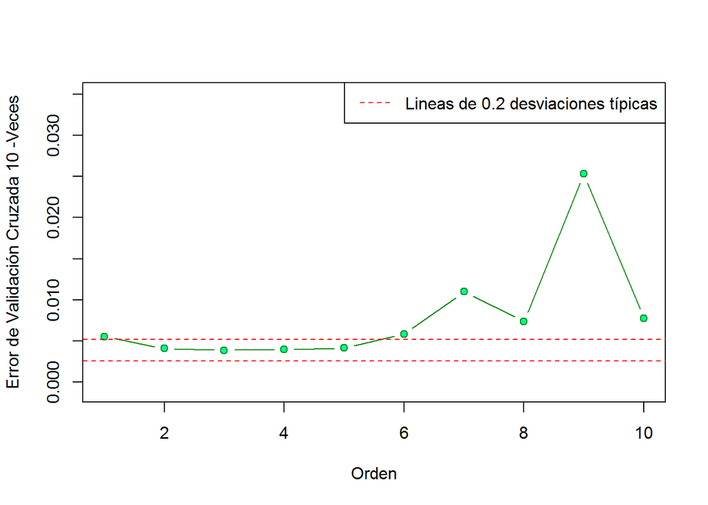

```r
plot_cv_error(cv_error_10, k=10, col="green4", bg="mediumspringgreen", ylim=c(-0.001, 0.035))
```

```r
lm_fit_3 = lm(nox~poly(dis, 3))
lm_fit_3$coefficients
```

```
##   (Intercept) poly(dis, 3)1 poly(dis, 3)2 poly(dis, 3)3
##     0.5546951    -2.0030959     0.8563300    -0.3180490
```

Veamos como el polinomio estimado se ajusta a la nube de puntos.

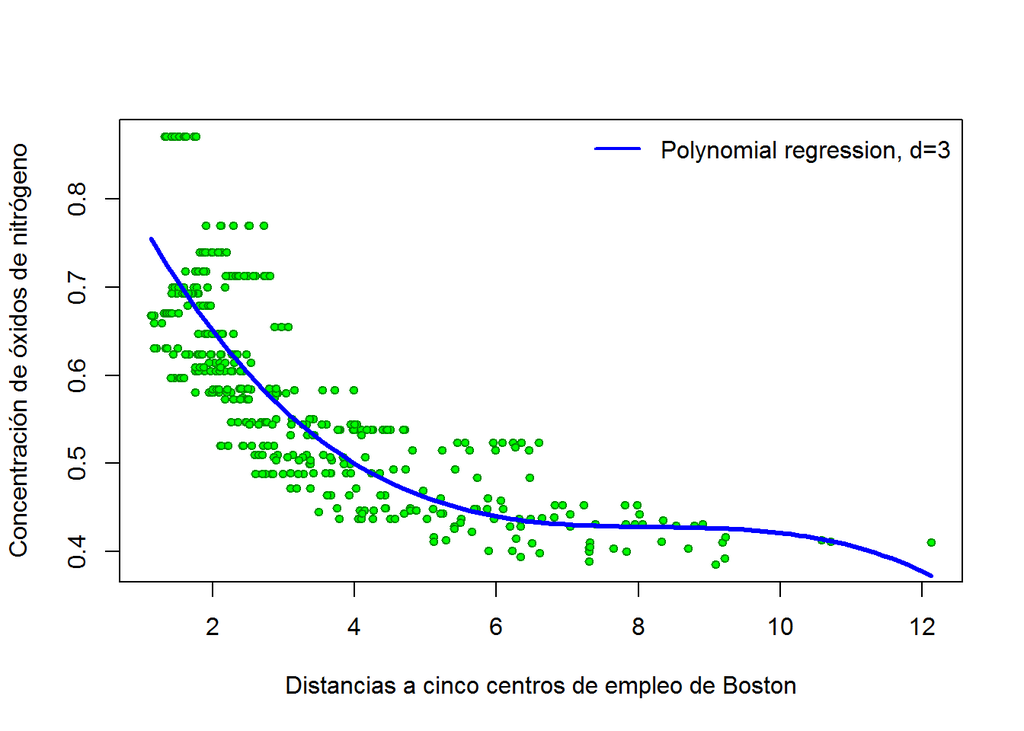

```r
plot(nox~dis, pch=21, cex=0.75, bg="green", col="green4", xlab="Distancias a cinco centros de empleo de Boston", ylab="Concentración de óxidos de nitrógeno")
curve(predict(lm_fit_3, data.frame(dis=x)), col='blue', lwd=3, add=TRUE)
legend("topright", legend="Polynomial regression, d=3", col="blue", lty =1, lwd=2, bty ="n")
```

- LOOCV. $K=n$, donde $n$ es el número de observaciones (trabajadores).

Repetimos el proceso por última vez para $k=n$.

```r
set.seed(78)
cv_error_n = cross_val(x=dis, y=nox)
cv_error_n
```

```
##  [1] 0.005523868 0.004079449 0.003874762 0.003887521 0.004164865
##  [6] 0.005384278 0.011068782 0.008121397 0.017616356 0.004430276
```

```r
cv_min = min(cv_error_n)
which(cv_error_n==cv_min)
```

```
## [1] 3
```

En este caso, el menor error se vuelve a cometer con un polinomio de grado 3. Visualicemos los errores para cada grado.

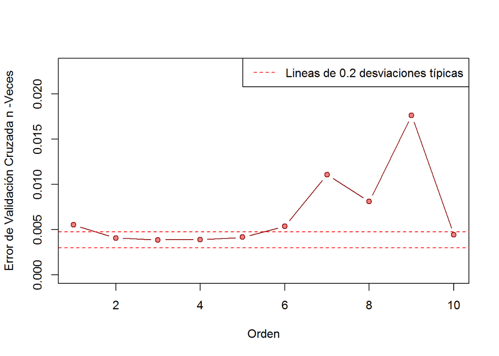

```r
plot_cv_error(cv_error_n, k="n", col="darkred", bg="lightcoral", ylim=c(0, 0.023))
```

El gráfico con la nube de puntos y la línea del polinomio será el mismo que para $k=10$.

Para poder comparar el resultado del método de validación cruzada para $k=5$, $k=10$ y $k=n$, dibujamos los errores $CV_{(K)}$ en un mismo gràfico.

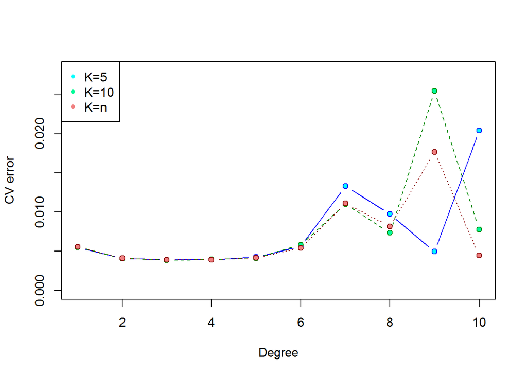

```r
matplot(1:10, cbind(cv_error_5, cv_error_10, cv_error_n), xlab="Degree", ylab="CV error", type="b", pch=21, lwd=1, col=c("blue","green4","darkred"), bg=c("cyan","mediumspringgreen","lightcoral"), ylim=c(0, 0.028))
legend("topleft",legend=c("K=5","K=10","K=n"), pch=20, col=c("cyan","mediumspringgreen","lightcoral"))
```

Para los grados del 1 al 6, no se aprecian cambios a esta escala, por lo tanto la modificamos.

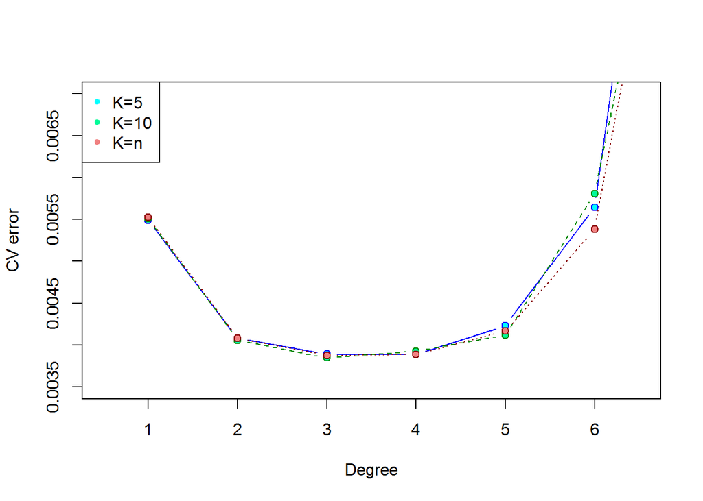

```r
matplot(1:10, cbind(cv_error_5, cv_error_10, cv_error_n), xlab="Degree", ylab="CV error", type="b", pch=21, lwd=1, col=c("blue","green4","darkred"), bg=c("cyan","mediumspringgreen","lightcoral"), ylim=c(0.0035, 0.007), xlim=c(0.5, 6.5))
legend("topleft",legend=c("K=5","K=10","K=n"), pch=20, col=c("cyan","mediumspringgreen","lightcoral"))
```

```r
detach(boston)
```

# Ejercicio 10

**Cargue la package “Lock5Data” y los datos “CommuteAtlanta”.**

```r
library(Lock5Data)
datos=CommuteAtlanta
head(datos)
```

| City | Age | Distance | Time | Sex |
| --- | --- | --- | --- | --- |
| Atlanta | 19 | 10 | 15 | M |
| Atlanta | 55 | 45 | 60 | M |
| Atlanta | 48 | 12 | 45 | M |
| Atlanta | 45 | 4 | 10 | F |
| Atlanta | 48 | 15 | 30 | F |
| Atlanta | 43 | 33 | 60 | M |

1. **De una estimación de la media poblacional de “Distance”. Llámela de $\tilde{\mu}$.**

Para dar una estimación de la media poblacional de Distance, lo que haremos serà la media de los valores de esta variable:

```r
mu_tilde=mean(datos$Distance)
mu_tilde
```

```
## [1] 18.156
```

2. **De una estimación del error estándar de $\tilde{\mu}$. Interprete este resultado.**

Para dar una estimación del error estándar de $\tilde{\mu}$, lo que haremos será calcular la desviación típica de los valores de esta variable distancia y los dividiremos por la raíz del numero de observaciones, es decir:

$$SE_\tilde{\mu}\ = \frac{s}{\sqrt{n}}$$

```r
s=sd(datos$Distance)
n=dim(datos)[1]
s/sqrt(n)
```

```
## [1] 0.6170777
```

Podemos observar que el error estándar es relativamente pequeño, en consecuencia los valores de la media muestral no oscilan demasiado alrededor del verdadero valor de la media poblacional.

3. **Ahora estime el error estándar de $\tilde{\mu}$ usando el Bootstrap con $B = 100 000$ muestras de boostrap. Compare los resultados con los del apartado (b).**

Construimos la función que nos calculará el error estandar de la media para el método Bootstrap:

```r
library(boot)

err.est.media=function(x){
  sd(x)/sqrt(length(x))
}

err.est.media.fn=function(data, index){
  with(data[index,],err.est.media(Distance))
}

boot.out=boot(datos,err.est.media.fn,R=100000)
boot.out
```

```
##
## ORDINARY NONPARAMETRIC BOOTSTRAP
##
##
## Call:
## boot(data = datos, statistic = err.est.media.fn, R = 1e+05)
##
##
## Bootstrap Statistics :
##      original      bias    std. error
## t1* 0.6170777 -0.00171124  0.03837772
```

Podemos observar que hemos obtenido la misma estimación del error estándar de $\tilde{\mu}$, como era de esperar (0.6170777) . Por otro lado, el bias (-0.0017112), es decir, la difencia valor entre el estimado y la media de las nuevas muestras, es pequeño y esto es bueno porque cuando más pequeño es, más pequeño será la desviación estándar. Finalmente, podemos ver que hemos obtenido que una desviación estándar muy pequeña (0.0383777), por lo que podemos decir que la estimación del error estándar para la media de la variable Distance es fiable.

4. **A partir de la estimación de Bootstrap del apartado (c), calcule un Intervalo de Confianza del 95% para la media poblacional de “Distance”. Utilice el método del percentil. Compare los resultados con el intervalo de confianza obtenido utilizando la distribución Normal.**

Para calcular el intervalo de confianza con el método del percentil cogeremos las 100000 estimaciones que se han considerado en la función boot del apartado anterior, las ordenaremos y nos quedaremos con el 95% central de las estimaciones:

```r
estimaciones=sort(boot.out$t,decreasing = FALSE)
lim_inf=round((length(estimaciones)+1)*(5/(2*100)))
lim_sup=round((length(estimaciones)+1)*(1-5/(2*100)))
intervalo=range(estimaciones[lim_inf:lim_sup])
intervalo
```

```
## [1] 0.5448715 0.6941028
```

Por otro lado calculemos intervalo obtenido utilizando la distribución normal. Como estamos cogiendo una muestra de estimaciones muy grande (100000) por el teorema central del límite $\tilde{\mu}$ se distribuye normalmente, en consecuencia podemos calcular un intervalo de confianza para la media poblacional de la siguiente forma:

$$\left( (T-\tilde{B}^*) - z_{1-\alpha/2}\tilde{SE}^*(T^*), (T-\tilde{B}^*) + z_{1-\alpha/2}\tilde{SE}^*(T^*) \right)$$

Como queremos un intervalo del 95%, entonces $\alpha=0.05$:

```r
T=boot.out$t0
Bias =-boot.out$t0+mean(boot.out$t)
z=qnorm(1-0.05/2)
SE=sd(boot.out$t)
liminf= (T-Bias)-z*SE
limsup=(T-Bias)+z*SE
T
```

```
## [1] 0.6170777
```

```r
Bias
```

```
## [1] -0.00171124
```

```r
z
```

```
## [1] 1.959964
```

```r
SE
```

```
## [1] 0.03837772
```

```r
liminf
```

```
## [1] 0.54357
```

```r
limsup
```

```
## [1] 0.6940079
```

Finalmente, podemos añadir que los dos invertalos obtenidos para cada métodos son prácticamente el mismo.

5. **De una estimación de la varianza poblacional de “Distance”. Llámela de $\tilde{\sigma}^2$.**

Para dar una estimación de la varianza poblacional, podemos calcular la varianza de los datos de la muestra:

```r
sigma_tilde=sd(datos$Distance)**2
sigma_tilde
```

```
## [1] 190.3924
```

6. **Estime el error estándar de $\tilde{\sigma}^2$ usando el Bootstrap con $B = 100000$ muestras de boostrap.**

Igual que en el apartado anterior, construimos la función que nos calculará el error estandar de la varianza para el método Bootstrap:

```r
err.est.varianza=function(x){
  sd(x)**2
}

err.est.varianza.fn=function(data, index){
  with(data[index,],err.est.varianza(Distance))
}

boot.out=boot(datos,err.est.varianza.fn,R=100000)
boot.out
```

```
##
## ORDINARY NONPARAMETRIC BOOTSTRAP
##
##
## Call:
## boot(data = datos, statistic = err.est.varianza.fn, R = 1e+05)
##
##
## Bootstrap Statistics :
##     original     bias    std. error
## t1* 190.3924 -0.4098442    23.79551
```

Como podemos apreciar, el error estándar es muy grande: 23.7955067, en consecuencia podemos decir que la estimación 190.3924489 para la varianza de la poblabión del apartado anterior no es muy fiable.

7. **Estime el percentil 25% poblacional de “Distance”. Llámelo de $\tilde{\mu}_{0.25}$ .**

Para estimar el 25% poblacional de la variable Distance podemos calcular el primer quartil de nuestra muestra:

```r
quartil1=  as.numeric(quantile(datos$Distance,prob=0.25))
quartil1
```

```
## [1] 8
```

8. **Estime el error estándar de $\tilde{\mu}_{0.25}$ usando el Bootstrap con $B = 100000$ muestras de boostrap. Interprete los resultados.**

Igual que en el apartado anterior, construimos la función que nos calculará el primer quartil para el método Bootstrap:

```r
err.est.quantile=function(x){
 as.numeric(quantile(x,prob=0.25))
}

err.est.quantile.fn=function(data, index){
  with(data[index,],err.est.quantile(Distance))
}

boot.out=boot(datos,err.est.quantile.fn,R=100000)
boot.out
```

```
##
## ORDINARY NONPARAMETRIC BOOTSTRAP
##
##
## Call:
## boot(data = datos, statistic = err.est.quantile.fn, R = 1e+05)
##
##
## Bootstrap Statistics :
##     original    bias    std. error
## t1*        8 0.4092925   0.8953342
```

Podemos observar que hemos obtenido la misma estimación del error estándar de $\tilde{\mu}$, como era de esperar (8) . Por otro lado, el bias (0.4092925) es pequeño y esto es bueno porque cuando más pequeño es, más pequeño será la desviación estándar. Finalmente, podemos ver que hemos obtenido que una desviación estándar muy pequeña (0.8953342), por lo que podemos decir que la estimación del primer quartil del apartado anterior en la variable Distance es fiable.

1. **A partir de la estimación de Bootstrap del apartado (h), calcule un Intervalo de Confianza del 95% para el percentil 25% poblacional de “Distance”. Utilice el método del percentil.**

Al igual que hemos realizado en el apartado d), para calcular el intervalo de confianza con el método del percentil cogeremos las 100000 estimaciones que se han considerado en la función boot del apartado anterior, las ordenaremos y nos quedaremos con el 95% central de las estimaciones:

```r
estimaciones=sort(boot.out$t,decreasing = FALSE)
lim_inf=round((length(estimaciones)+1)*(5/(2*100)))
lim_sup=round((length(estimaciones)+1)*(1-5/(2*100)))
intervalo=range(estimaciones[lim_inf:lim_sup])
intervalo
```

```
## [1]  7 10
```

En consecuencia el intervalo obtenido es (7,10). Esto implica que en un 95% de los casos el verdadero valor del primer quartil de la población se encontrará en este intervalo.